# Risk Skepticism Survey Pilot Study

Data Quality Inspection

Author

Risk Rejection Team: Guannan Shen

Published

September 11, 2024

# Data Cleaning Process

## Raw Data

There are 703 subjects participated in this survey, and the raw dataset has 499 columns.

## Screening

Frequency and Percentage of Pass_screening

| Pass_screening | Frequency Count | Percentage (%) |
| --- | --- | --- |
| No | 70 | 9.957 |
| Yes | 624 | 88.762 |
| NA | 9 | 1.280 |
| Sum | 703 | 100.000 |

Check Missingness: Risks (screening failed)

| Columns | Missing_Count | Missing_percentage |
| --- | --- | --- |
| Experimental condition | 70 | 100% |
| abs_risk_rounded | 70 | 100% |
| abs_risk_pct | 70 | 100% |
| abs_risk_lifetime_rounded | 70 | 100% |
| abs_risk_age_group_rounded | 70 | 100% |
| abs_risk_age_group_pct | 70 | 100% |
| abs_risk_no_cancer_cohort | 70 | 100% |
| abs_risk_age_group_no_cancer_cohort | 70 | 100% |
| 50yr_absolute_risk | 70 | 100% |
| 50yr_absolute_risk_lifetime | 70 | 100% |
| 50yr_absolute_risk_age_group | 70 | 100% |
| 50yr_RR_Star1 | 70 | 100% |
| 50yr_RR_Star2 | 70 | 100% |
| 50yr_abs_risk_rounded | 70 | 100% |
| 50yr_abs_risk_pct | 70 | 100% |
| 50yr_abs_risk_lifetime_rounded | 70 | 100% |
| 50yr_abs_risk_age_group_rounded | 70 | 100% |
| 50yr_abs_risk_age_group_pct | 70 | 100% |
| 50yr_abs_risk_no_cancer_cohort | 70 | 100% |
| abs_risk_relative_text | 70 | 100% |
| 50yr_abs_risk_age_group_no_cancer_cohort | 70 | 100% |

Check Missingness: Risks Rejections (screening failed)

| Columns | Missing_Count | Missing_percentage |
| --- | --- | --- |
| RReject1 | 70 | 100% |
| RReject2 | 70 | 100% |
| RReject3 | 70 | 100% |
| RReject4 | 70 | 100% |
| RReject5 | 70 | 100% |
| RReject6 | 70 | 100% |
| RReject7 | 70 | 100% |

For 9 subjects with completely missing data (even the screening answers are missing). Those 9 subjects are excluded from the dataset.

### With Screening

70 subjects who did not pass the screening were excluded from the dataset.

### Check Group Design

Each category (1-3) should have approximately 30% of observations (**Checklist 1**). The key question `Pre-estimate` have answers in only 2 of the 3 experimental conditions, no answer for condition #3 (**Checklist 2**).

Frequency and Percentage of Experimental condition

| Experimental condition | Frequency Count | Percentage (%) |
| --- | --- | --- |
| 1 | 186 | 29.808 |
| 2 | 214 | 34.295 |
| 3 | 209 | 33.494 |
| NA | 15 | 2.404 |
| Sum | 624 | 100.000 |

Cross-Frequency Table Between missingness_Experimental condition and Finished

| missingness_Experimental condition | Finished 0 | Finished 1 | Finished Sum |
| --- | --- | --- | --- |
| missing | 15 | 0 | 15 |
| nonmissing | 100 | 509 | 609 |
| Sum | 115 | 509 | 624 |

Check Missingness: Risks (No Experimental Condition)

| Columns | Missing_Count | Missing_percentage |
| --- | --- | --- |
| Experimental condition | 15 | 100% |
| abs_risk_rounded | 15 | 100% |
| abs_risk_pct | 15 | 100% |
| abs_risk_lifetime_rounded | 15 | 100% |
| abs_risk_age_group_rounded | 15 | 100% |
| abs_risk_age_group_pct | 15 | 100% |
| abs_risk_no_cancer_cohort | 15 | 100% |
| abs_risk_age_group_no_cancer_cohort | 15 | 100% |
| 50yr_absolute_risk | 15 | 100% |
| 50yr_absolute_risk_lifetime | 15 | 100% |
| 50yr_absolute_risk_age_group | 15 | 100% |
| 50yr_RR_Star1 | 15 | 100% |
| 50yr_RR_Star2 | 15 | 100% |
| 50yr_abs_risk_rounded | 15 | 100% |
| 50yr_abs_risk_pct | 15 | 100% |
| 50yr_abs_risk_lifetime_rounded | 15 | 100% |
| 50yr_abs_risk_age_group_rounded | 15 | 100% |
| 50yr_abs_risk_age_group_pct | 15 | 100% |
| 50yr_abs_risk_no_cancer_cohort | 15 | 100% |
| abs_risk_relative_text | 15 | 100% |
| 50yr_abs_risk_age_group_no_cancer_cohort | 15 | 100% |

Check Missingness: Risks Rejections (No Experimental Condition)

| Columns | Missing_Count | Missing_percentage |
| --- | --- | --- |
| RReject1 | 15 | 100% |
| RReject2 | 15 | 100% |
| RReject3 | 15 | 100% |
| RReject4 | 15 | 100% |
| RReject5 | 15 | 100% |
| RReject6 | 15 | 100% |
| RReject7 | 15 | 100% |

There are missingness in **Experimental Condition**. Based on above result, 15 subjects who did not have Experimental Condition were excluded from the dataset.

Now the **sample size is 609**.

Cross-Frequency Table Between Experimental condition and Pre-estimate

| Experimental condition | Pre-estimate 1 | Pre-estimate 2 | Pre-estimate 3 | Pre-estimate NA | Pre-estimate Sum |
| --- | --- | --- | --- | --- | --- |
| 1 | 30 | 104 | 48 | 4 | 186 |
| 2 | 37 | 122 | 51 | 4 | 214 |
| 3 | 0 | 0 | 0 | 209 | 209 |
| Sum | 67 | 226 | 99 | 217 | 609 |

Check Missingness: Risks

| Columns | Missing_Count | Missing_percentage |
| --- | --- | --- |
| 50yr_absolute_risk | 51 | 8.37% |
| 50yr_absolute_risk_lifetime | 51 | 8.37% |
| 50yr_absolute_risk_age_group | 51 | 8.37% |
| 50yr_RR_Star1 | 51 | 8.37% |
| 50yr_RR_Star2 | 51 | 8.37% |
| abs_risk_rounded | 16 | 2.63% |
| abs_risk_pct | 16 | 2.63% |
| abs_risk_lifetime_rounded | 16 | 2.63% |
| abs_risk_age_group_rounded | 16 | 2.63% |
| abs_risk_age_group_pct | 16 | 2.63% |
| abs_risk_no_cancer_cohort | 16 | 2.63% |
| abs_risk_age_group_no_cancer_cohort | 16 | 2.63% |
| 50yr_abs_risk_rounded | 16 | 2.63% |
| 50yr_abs_risk_pct | 16 | 2.63% |
| 50yr_abs_risk_lifetime_rounded | 16 | 2.63% |
| 50yr_abs_risk_age_group_rounded | 16 | 2.63% |
| 50yr_abs_risk_age_group_pct | 16 | 2.63% |
| 50yr_abs_risk_no_cancer_cohort | 16 | 2.63% |
| abs_risk_relative_text | 16 | 2.63% |
| 50yr_abs_risk_age_group_no_cancer_cohort | 16 | 2.63% |
| Experimental condition | 0 | 0% |

Check Missingness: Risks Rejections

| Columns | Missing_Count | Missing_percentage |
| --- | --- | --- |
| RReject2 | 54 | 8.87% |
| RReject6 | 54 | 8.87% |
| RReject3 | 53 | 8.7% |
| RReject4 | 53 | 8.7% |
| RReject5 | 53 | 8.7% |
| RReject7 | 53 | 8.7% |
| RReject1 | 50 | 8.21% |

Check Missingness: Risks (Pre-estimate wrong missing)

| Columns | Missing_Count | Missing_percentage |
| --- | --- | --- |
| abs_risk_rounded | 8 | 100% |
| abs_risk_pct | 8 | 100% |
| abs_risk_lifetime_rounded | 8 | 100% |
| abs_risk_age_group_rounded | 8 | 100% |
| abs_risk_age_group_pct | 8 | 100% |
| abs_risk_no_cancer_cohort | 8 | 100% |
| abs_risk_age_group_no_cancer_cohort | 8 | 100% |
| 50yr_absolute_risk | 8 | 100% |
| 50yr_absolute_risk_lifetime | 8 | 100% |
| 50yr_absolute_risk_age_group | 8 | 100% |
| 50yr_RR_Star1 | 8 | 100% |
| 50yr_RR_Star2 | 8 | 100% |
| 50yr_abs_risk_rounded | 8 | 100% |
| 50yr_abs_risk_pct | 8 | 100% |
| 50yr_abs_risk_lifetime_rounded | 8 | 100% |
| 50yr_abs_risk_age_group_rounded | 8 | 100% |
| 50yr_abs_risk_age_group_pct | 8 | 100% |
| 50yr_abs_risk_no_cancer_cohort | 8 | 100% |
| abs_risk_relative_text | 8 | 100% |
| 50yr_abs_risk_age_group_no_cancer_cohort | 8 | 100% |
| Experimental condition | 0 | 0% |

Check Missingness: Risks Rejections (Pre-estimate wrong missing)

| Columns | Missing_Count | Missing_percentage |
| --- | --- | --- |
| RReject1 | 8 | 100% |
| RReject2 | 8 | 100% |
| RReject3 | 8 | 100% |
| RReject4 | 8 | 100% |
| RReject5 | 8 | 100% |
| RReject6 | 8 | 100% |
| RReject7 | 8 | 100% |

Based on the above missingness analysis, the 8 subjects with wrong pre-estimate missingness are excluded from the dataset.

Now, the **sample size is 601.**

## Missingness Pattern

The Upper graph is the missingness heatmap for experimental condition columns, 20 risks columns and, 7 risk rejection columns, of all 601 subjects.

The lower graph is the missingness heatmap for the same population, but for all columns other than “timer” related columns.

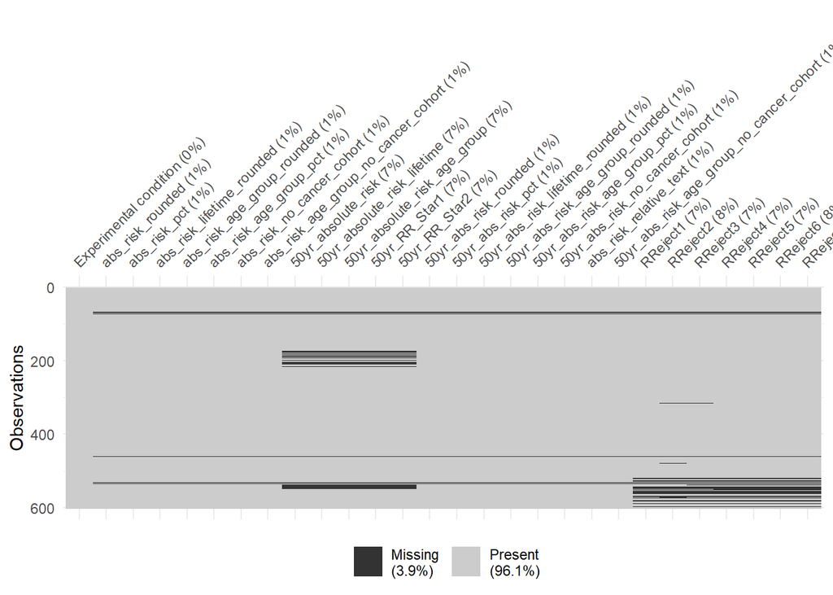

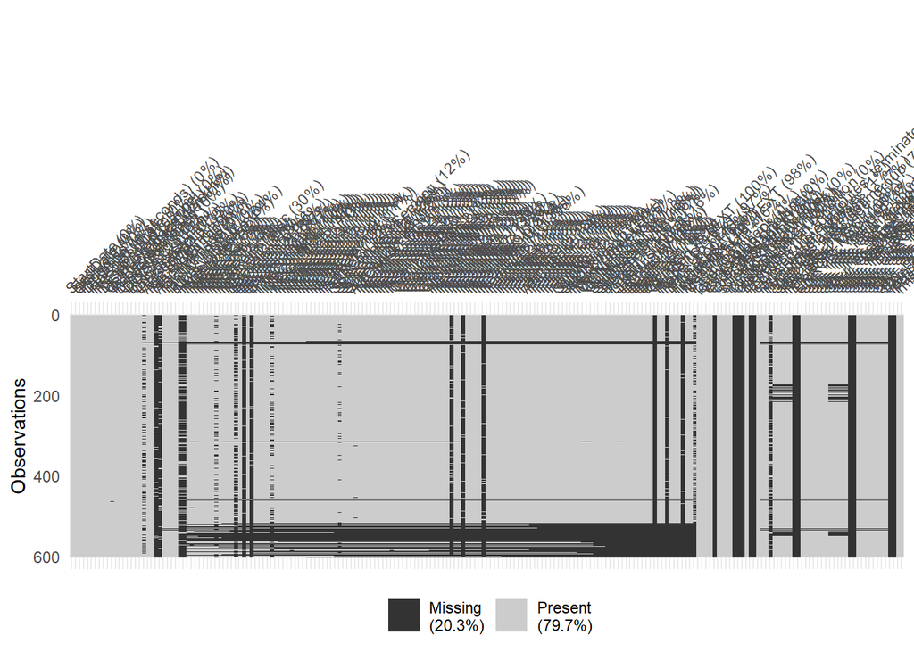

Missingness proportion per observation

risks_missing_prop_obs > 0 OR total_missing_prop_obs > 0.095 (1.0000 means 100% missing)

| Response ID | risks_missing_prop_obs | total_missing_prop_obs |
| --- | --- | --- |
| R_089p1zlaLG8OHa9 | 1.0000 | 0.9321 |
| R_2Ui5BpmQfsHHKaV | 1.0000 | 0.9281 |
| R_271mSEzsj9xF73r | 1.0000 | 0.9281 |
| R_24Obn0v6s7AcOS9 | 1.0000 | 0.9042 |
| R_3j11kskwq4NRquQ | 1.0000 | 0.9042 |
| R_2DM6Im4BSv0Qpzj | 1.0000 | 0.9022 |
| R_24Axp973AlLPE2t | 1.0000 | 0.9022 |
| R_1jJxnC6KSzmG62F | 1.0000 | 0.8942 |
| R_2c8gTVQgo1LEvmG | 0.4444 | 0.8463 |
| R_2cCbrFLzwFLpbs6 | 0.4444 | 0.8363 |
| R_XgCe2lAn1q1ax3j | 0.4444 | 0.8363 |
| R_2U4qw2hQBsjk52K | 0.4444 | 0.8363 |
| R_1mPZrKYeDhXcH4E | 0.4444 | 0.8224 |
| R_UAsPoonUFKV2DsJ | 0.4444 | 0.8224 |
| R_10AUDBOC2ppqcG6 | 0.3704 | 0.8244 |
| R_sMZCbuO9YycMcVj | 0.2593 | 0.8423 |
| R_27mvz82XgkAaXZq | 0.2593 | 0.8423 |
| R_3jcAhyai62THxVP | 0.2593 | 0.8343 |
| R_1dbgscRPWV1mRQw | 0.2593 | 0.8343 |
| R_3O7wlmix2UGR0Ks | 0.2593 | 0.8323 |
| R_2ckktaKzGD0Ikfq | 0.2593 | 0.8323 |
| R_OJyePMRkPpXxHDH | 0.2593 | 0.8283 |
| R_2qvZ3uyrTZJufco | 0.2593 | 0.8263 |
| R_2an7rZypp6xGAR9 | 0.2593 | 0.8263 |
| R_3nwtgBh4LSRsNWW | 0.2593 | 0.8263 |
| R_1IgilLMyrpovngu | 0.2593 | 0.8263 |
| R_3MEEzwMmTEmJibG | 0.2593 | 0.8224 |
| R_VIpPco2T5Rqafg5 | 0.2593 | 0.8164 |
| R_1ooHllkK5iiowel | 0.2593 | 0.8164 |
| R_1CEm3Sd7k8ERNNk | 0.2593 | 0.8164 |

[output cut: 94 more lines]

### Missingness First Impression

Based on the missingness pattern heatmap, we can tell, some observations have abnormally consistent missing values. Those observations are likely to have missingness for most of their input values. Thus, the above missingness proportion per observation table was generated, and only subjects with missing proportion “risks_missing_prop_obs > 0 OR total_missing_prop_obs > 0.095” were shown in the table. The risks_missing_prop_obs is the measurement of missingness for 20 risks columns and 7 risk rejections cols. The total_missing_prop_obs is the measurement of overall missingness including more than 500 columns.

## Subjects Filtering According to Missingness

Based on the above table, there are **43 subjects** with obvious worst sparsity, colored in red.

Further demonstration of missingness pattern in the most sparse subset and remaining subset are shown below.

### Missingness Pattern of the Most Sparse Subset

Upper figure for 20 risks columns and 7 risk rejections cols.

Lower figure for all columns after excluding “timer” related columns.

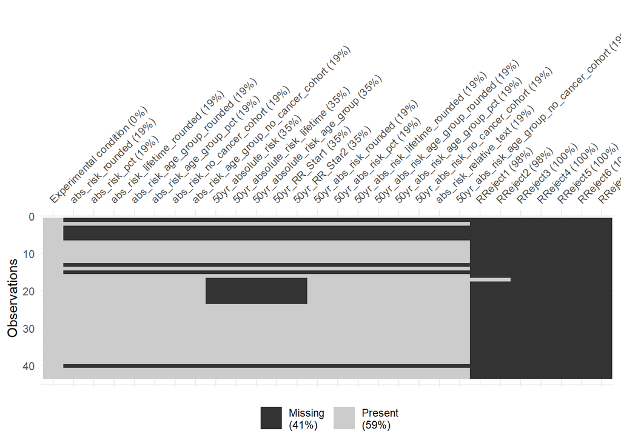

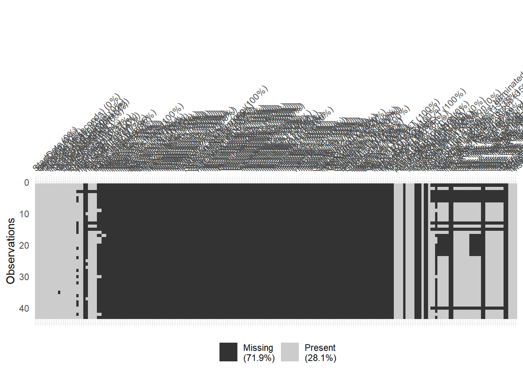

### Missingness Pattern of the Remaining Subset

After filtering out the most incomplete subset, the **sample size now is 558**.

Upper figure for 20 risks columns and 7 risk rejections cols.

Lower figure for all columns after excluding “timer” related columns.

Then, check missingness by observation again, using table.

At last, double check the balanced group design.

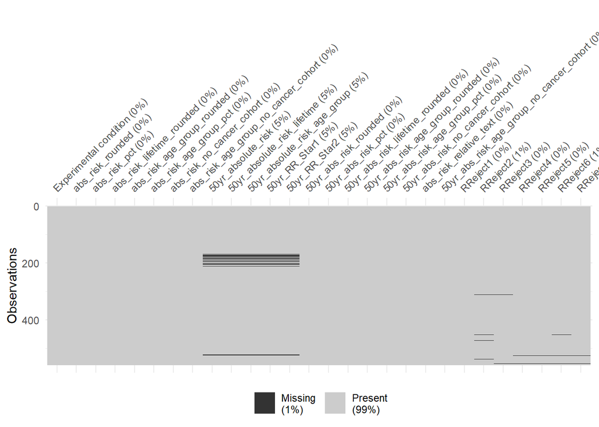

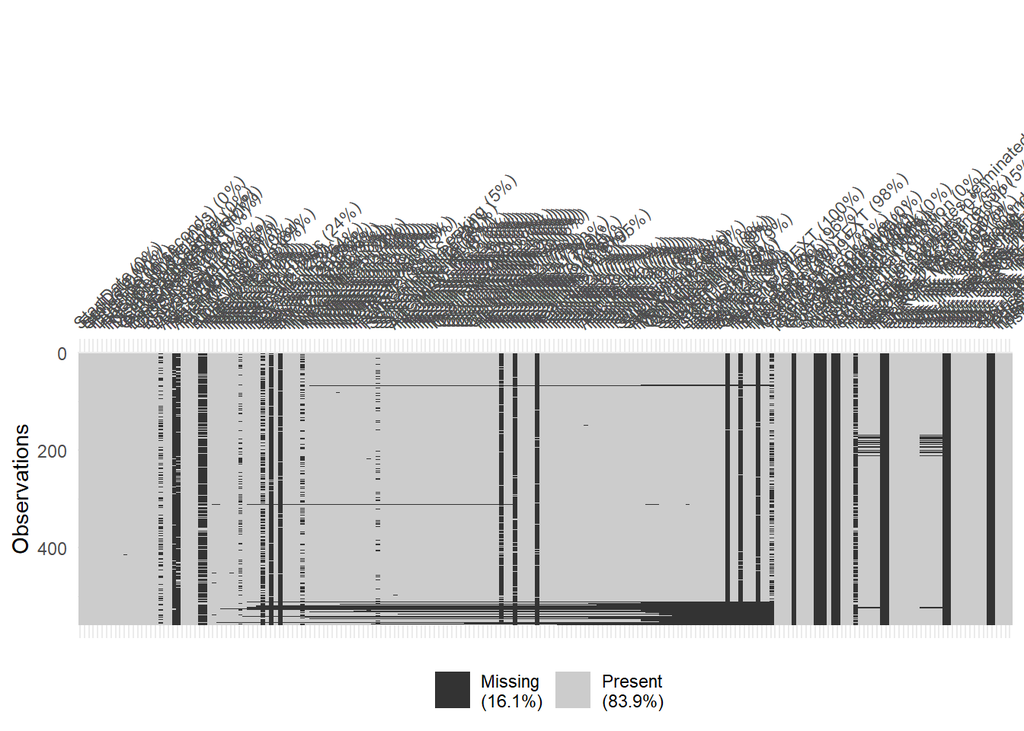

Missingness proportion per observation (After Exclusion the Worst Missing)

risks_missing_prop_obs > 0 OR total_missing_prop_obs > 0.095 (1.0000 means 100% missing)

| Response ID | risks_missing_prop_obs | total_missing_prop_obs |
| --- | --- | --- |
| R_23fyLWBd86Gthif | 0.1852 | 0.8004 |
| R_1nNNav4bLavcgno | 0.1481 | 0.7844 |
| R_2ZJk9dTc2ndY3d2 | 0.1852 | 0.7784 |
| R_uy5Linn7NulydFL | 0.1852 | 0.7784 |
| R_3lyH1i2jabV4WhO | 0.0000 | 0.7685 |
| R_1jZdhu7YM8refIZ | 0.0000 | 0.7605 |
| R_9YJuzZcEuK2I3VT | 0.0000 | 0.7605 |
| R_1r1Do4UxESRik6c | 0.0000 | 0.7585 |
| R_3MA2ywj8nt1DEfT | 0.0000 | 0.7585 |
| R_25KKVWUbNoe6ZeJ | 0.0000 | 0.7505 |
| R_22M2Rg1TqDIfmVK | 0.0000 | 0.7465 |
| R_6ffvtOWHkeqszv3 | 0.0000 | 0.7465 |
| R_uyMmAHecvVe4P1D | 0.0000 | 0.7465 |
| R_3lYtLpS00kLRZwm | 0.0000 | 0.7206 |
| R_3I4WOy4bxnqzGc6 | 0.0000 | 0.7166 |
| R_cUgISEYmtG0QrYZ | 0.0000 | 0.7166 |
| R_3CMlSv3ontyObrH | 0.0000 | 0.7086 |
| R_3PmJZgjcpmNGyUO | 0.0000 | 0.7006 |
| R_1jwjAF4OQ97oxoh | 0.0000 | 0.6986 |
| R_2UaSkSppxAiSsry | 0.0000 | 0.6926 |
| R_2bDhvG9L34r8MUh | 0.0000 | 0.6806 |
| R_3hiqe2wR3PKuQn6 | 0.0000 | 0.6786 |
| R_2Yh8t2kIGqyfCtJ | 0.0000 | 0.6447 |
| R_SUCTInIndisB0XL | 0.0000 | 0.6427 |
| R_3MbWAG8DCDzuv6O | 0.0000 | 0.6407 |
| R_2bWdRlvI8tcuS7H | 0.0000 | 0.6307 |
| R_3OrhEEqbOX3Lc8a | 0.0000 | 0.6307 |
| R_3lxIazg9J9ZWNy3 | 0.1852 | 0.6128 |
| R_WeeIP8PhXmKFahP | 0.0000 | 0.6088 |
| R_2cAW20pDv42JawG | 0.0000 | 0.5908 |

[output cut: 51 more lines]

Frequency and Percentage of Experimental condition

| Experimental condition | Frequency Count | Percentage (%) |
| --- | --- | --- |
| 1 | 167 | 29.928 |
| 2 | 198 | 35.484 |
| 3 | 193 | 34.588 |
| Sum | 558 | 100.000 |

Cross-Frequency Table Between Experimental condition and Pre-estimate

| Experimental condition | Pre-estimate 1 | Pre-estimate 2 | Pre-estimate 3 | Pre-estimate NA | Pre-estimate Sum |
| --- | --- | --- | --- | --- | --- |
| 1 | 30 | 91 | 46 | 0 | 167 |
| 2 | 36 | 115 | 47 | 0 | 198 |
| 3 | 0 | 0 | 0 | 193 | 193 |
| Sum | 66 | 206 | 93 | 193 | 558 |

# Conclusion

**The above missingness pattern figures and table suggest the dataset may require further filtering.** This might need a group discussion.

[figure not shown]